# Assignment_9

Kai Pauole

2026-04-14

## Data

Here I will inspect the data GradSchool_Admissions and predict the chances of graduating.

```r
# load packages
library(tidyverse)
```

```r
library(ggplot2)
library(easystats)
library(broom)
# load data
graduation = read.csv("GradSchool_Admissions.csv")
```

```r
head(graduation)
```

```
##   admit gre  gpa rank
## 1     0 380 3.61    3
## 2     1 660 3.67    3
## 3     1 800 4.00    1
## 4     1 640 3.19    4
## 5     0 520 2.93    4
## 6     1 760 3.00    2
```

```r
str(graduation)
```

```
## 'data.frame':    400 obs. of  4 variables:
##  $ admit: int  0 1 1 1 0 1 1 0 1 0 ...
##  $ gre  : int  380 660 800 640 520 760 560 400 540 700 ...
##  $ gpa  : num  3.61 3.67 4 3.19 2.93 3 2.98 3.08 3.39 3.92 ...
##  $ rank : int  3 3 1 4 4 2 1 2 3 2 ...
```

Data need to be cleaned a bit. Rank needs to change to a factor. Also need to look for any missing values.

```r
# Convert rank to factor
graduation$rank <- as.factor(graduation$rank)

# check for na or missing
sum(is.na(graduation))
```

```
## [1] 0
```

## Exploratory Data Analysis

First I will look at GPA vs. admit

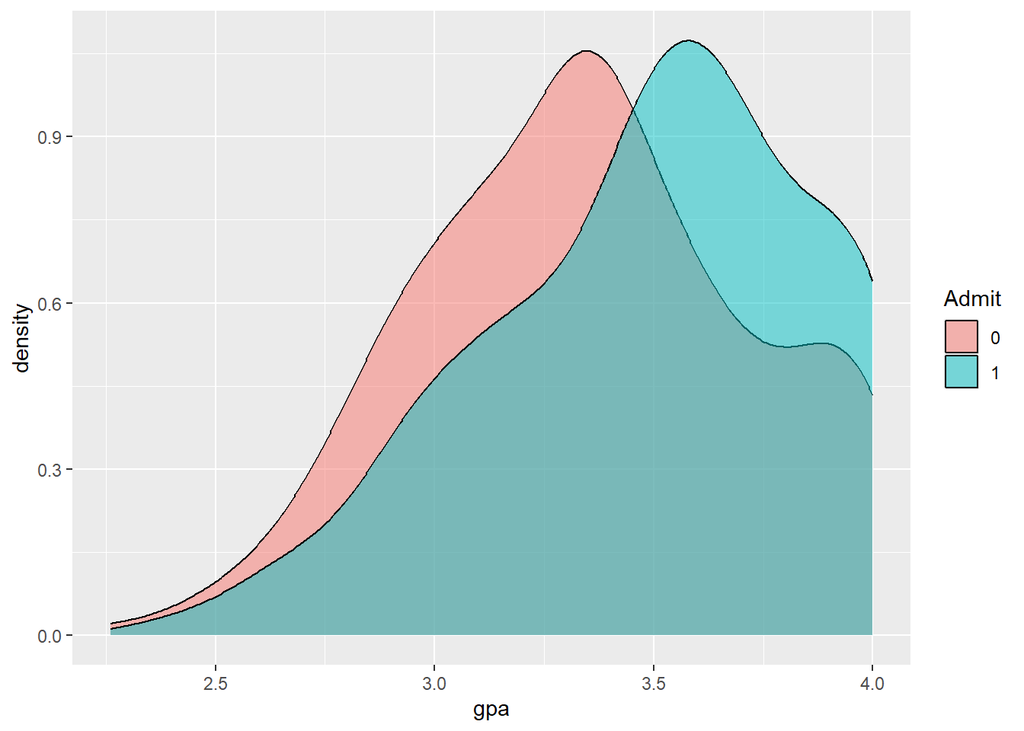

```r
ggplot(graduation, aes(x = gpa, fill = factor(admit))) +
  geom_density(alpha = 0.5) +
  labs(fill = "Admit")
```

This shows that even if someone got a high GPA does not guarantee acceptance, but your chances are higher.

Second GRV vs. admit

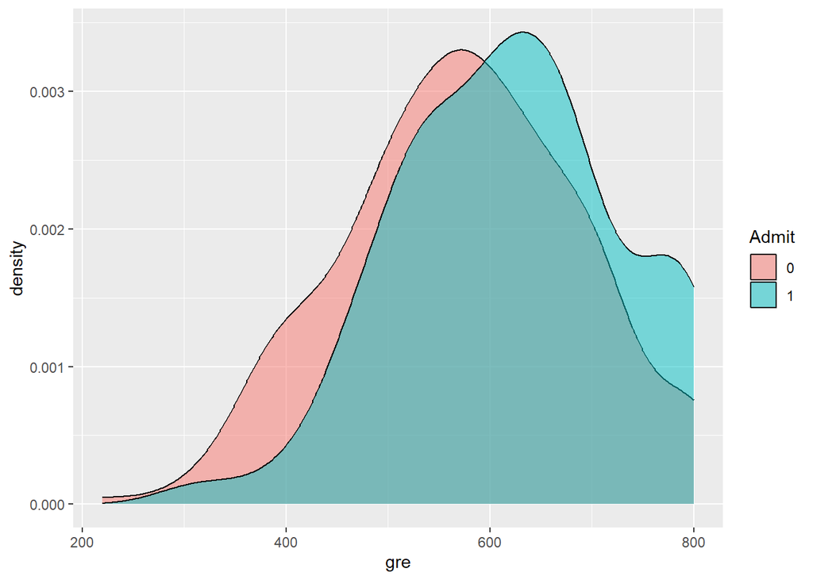

```r
ggplot(graduation, aes(x = gre, fill = factor(admit))) +
  geom_density(alpha = 0.5) +
  labs(fill = "Admit")
```

This shows that Even with a high GRE you also do not have a chance of getting in, but your chances are higher.

Lastly rank vs. admit, because of the values of rank I will just use a bar graph

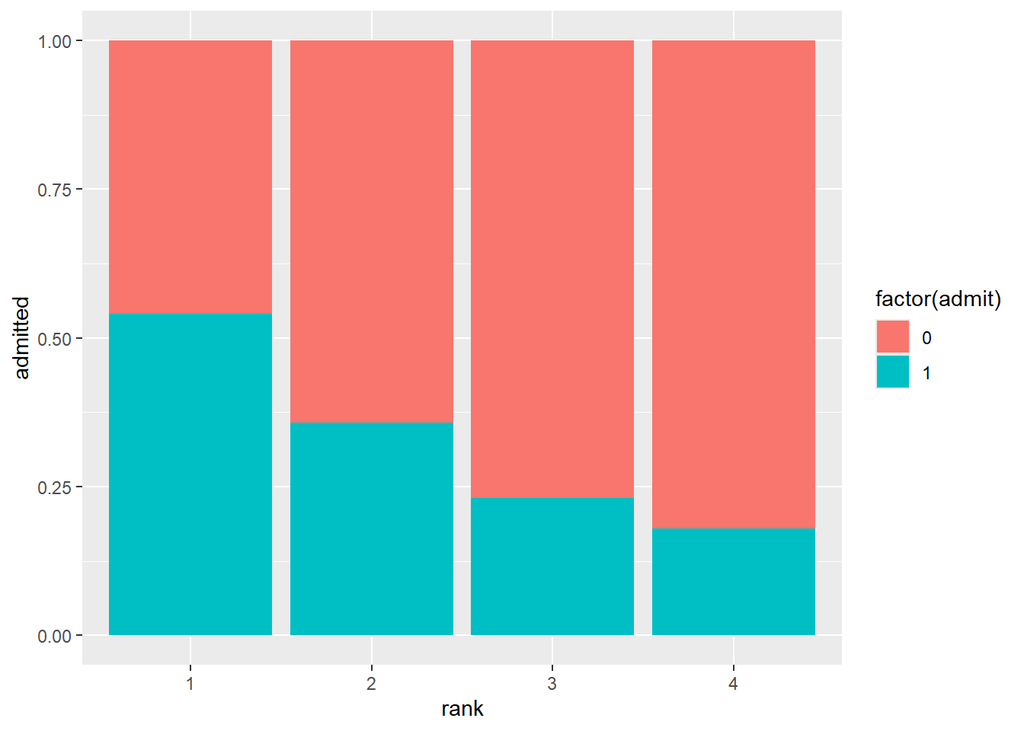

```r
ggplot(graduation, aes(x = rank, fill = factor(admit))) + geom_bar(position = 'fill') + labs(y = 'admitted')
```

This does seem to show that rank of the institution you attend increases the chance of getting admitted.

How do these correlate? Lets explore.

```r
mod1 = glm(admit ~ gre + gpa + rank,
              data = graduation,
              family = binomial)

summary(mod1)
```

```
##
## Call:
## glm(formula = admit ~ gre + gpa + rank, family = binomial, data = graduation)
##
## Coefficients:
##              Estimate Std. Error z value Pr(>|z|)
## (Intercept) -3.989979   1.139951  -3.500 0.000465 ***
## gre          0.002264   0.001094   2.070 0.038465 *
## gpa          0.804038   0.331819   2.423 0.015388 *
## rank2       -0.675443   0.316490  -2.134 0.032829 *
## rank3       -1.340204   0.345306  -3.881 0.000104 ***
## rank4       -1.551464   0.417832  -3.713 0.000205 ***
## ---
## Signif. codes:  0 '***' 0.001 '**' 0.01 '*' 0.05 '.' 0.1 ' ' 1
##
## (Dispersion parameter for binomial family taken to be 1)
##
##     Null deviance: 499.98  on 399  degrees of freedom
## Residual deviance: 458.52  on 394  degrees of freedom
## AIC: 470.52
##
## Number of Fisher Scoring iterations: 4
```

Rank, gpa, and gre together are needed to make the best predictions.

## Predictions

Here we will make predictions

```r
graduation$predicted_prob = predict(mod1, type = "response")

head(graduation)
```

```
##   admit gre  gpa rank predicted_prob
## 1     0 380 3.61    3      0.1726265
## 2     1 660 3.67    3      0.2921750
## 3     1 800 4.00    1      0.7384082
## 4     1 640 3.19    4      0.1783846
## 5     0 520 2.93    4      0.1183539
## 6     1 760 3.00    2      0.3699699
```

This shows the probability of getting admitted based on all three values.